# Results and Figures

Alex Kale

2/11/2020

In this document, we create the queries and visualizations that drive our reporting of results.

## Load in Data

This is the data we used to fit the models.

```r
# read in data
model_df <- read_csv("model-data.csv")
# preprocessing
model_df <- model_df %>%
  mutate(
    # factors for modeling
    means = as.factor(means),
    start_means = as.factor(start_means),
    sd_diff = as.factor(sd_diff),
    # evidence scale for decision model
    p_diff = p_award_with - (p_award_without + (1 / award_value)),
    evidence = qlogis(p_award_with) - qlogis(p_award_without + (1 / award_value))
  )
```

## Probability of Superiority

We load in the model of probability of superiority judgments that we arrived at through a process of model expansion described in our preregistration[https://osf.io/9kpmb]. This is basically a hierachical linear model of probability of superiority judgments where both judgments and the ground truth have been transformed onto a log odds scale. We call this a linear log odds model. See the paper and **experiment/analysis/PSuperiority.Rmd** in the supplemental materials for details.

```r
# hierarchical linear log odds model
m.p_sup <- brm(data = model_df, family = "gaussian",
             formula = bf(lo_p_sup ~  (1 + lo_ground_truth*trial + means*sd_diff|worker_id) + lo_ground_truth*means*sd_diff*condition*start_means + lo_ground_truth*condition*trial,
                          sigma ~ (1 + lo_ground_truth + trial|worker_id) + lo_ground_truth*condition*trial + means*start_means),
             prior = c(prior(normal(1, 0.5), class = b),
                       prior(normal(1.3, 1), class = Intercept),
                       prior(normal(0, 0.15), class = sd, group = worker_id),
                       prior(normal(0, 0.3), class = b, dpar = sigma),
                       prior(normal(0, 0.15), class = sd, dpar = sigma),
                       prior(lkj(4), class = cor)),
             iter = 12000, warmup = 2000, chains = 2, cores = 2, thin = 2,
             control = list(adapt_delta = 0.99, max_treedepth = 12),
             file = "model-fits/llo_mdl-min-r_means_sd_trial_block_sigma_gt_trial_means_block")
```

```r
summary(m.p_sup)
```

```
##  Family: gaussian
##   Links: mu = identity; sigma = log
## Formula: lo_p_sup ~ (1 + lo_ground_truth * trial + means * sd_diff | worker_id) + lo_ground_truth * means * sd_diff * condition * start_means + lo_ground_truth * condition * trial
##          sigma ~ (1 + lo_ground_truth + trial | worker_id) + lo_ground_truth * condition * trial + means * start_means
##    Data: model_df (Number of observations: 19892)
## Samples: 2 chains, each with iter = 12000; warmup = 2000; thin = 2;
##          total post-warmup samples = 10000
##
## Group-Level Effects:
## ~worker_id (Number of levels: 622)
##                                                Estimate Est.Error l-95% CI
## sd(Intercept)                                      0.06      0.01     0.05
## sd(lo_ground_truth)                                0.39      0.01     0.37
## sd(trial)                                          0.03      0.01     0.00
## sd(meansTRUE)                                      0.03      0.01     0.02
## sd(sd_diff15)                                      0.08      0.01     0.07
## sd(lo_ground_truth:trial)                          0.24      0.02     0.21
## sd(meansTRUE:sd_diff15)                            0.06      0.01     0.04
## sd(sigma_Intercept)                                1.18      0.03     1.12
## sd(sigma_lo_ground_truth)                          0.41      0.01     0.38
## sd(sigma_trial)                                    1.18      0.04     1.11
## cor(Intercept,lo_ground_truth)                    -0.47      0.09    -0.64
## cor(Intercept,trial)                               0.20      0.23    -0.30
## cor(lo_ground_truth,trial)                        -0.24      0.23    -0.64
## cor(Intercept,meansTRUE)                           0.03      0.19    -0.32
## cor(lo_ground_truth,meansTRUE)                    -0.60      0.13    -0.81
## cor(trial,meansTRUE)                               0.19      0.24    -0.33
## cor(Intercept,sd_diff15)                          -0.01      0.11    -0.22
## cor(lo_ground_truth,sd_diff15)                     0.03      0.09    -0.15
## cor(trial,sd_diff15)                               0.01      0.22    -0.44
## cor(meansTRUE,sd_diff15)                           0.01      0.17    -0.33
## cor(Intercept,lo_ground_truth:trial)              -0.28      0.10    -0.46
## cor(lo_ground_truth,lo_ground_truth:trial)         0.41      0.06     0.29
## cor(trial,lo_ground_truth:trial)                  -0.34      0.24    -0.71
## cor(meansTRUE,lo_ground_truth:trial)              -0.14      0.16    -0.44
## cor(sd_diff15,lo_ground_truth:trial)               0.07      0.09    -0.10
## cor(Intercept,meansTRUE:sd_diff15)                -0.33      0.13    -0.59
## cor(lo_ground_truth,meansTRUE:sd_diff15)           0.23      0.13    -0.04
## cor(trial,meansTRUE:sd_diff15)                     0.16      0.23    -0.32
## cor(meansTRUE,meansTRUE:sd_diff15)                 0.03      0.19    -0.33
```

[output cut: 675 more lines]

```
## sigma_lo_ground_truth:conditionHOPs                                        7173
## sigma_lo_ground_truth:conditionintervals                                   6236
## sigma_lo_ground_truth:conditionQDPs                                        6196
## sigma_lo_ground_truth:trial                                                8697
## sigma_conditionHOPs:trial                                                  8350
## sigma_conditionintervals:trial                                             8367
## sigma_conditionQDPs:trial                                                  9156
## sigma_meansTRUE:start_meansTRUE                                            8632
## sigma_lo_ground_truth:conditionHOPs:trial                                  8474
## sigma_lo_ground_truth:conditionintervals:trial                             8765
## sigma_lo_ground_truth:conditionQDPs:trial                                  8967
##
## Samples were drawn using sampling(NUTS). For each parameter, Eff.Sample
## is a crude measure of effective sample size, and Rhat is the potential
## scale reduction factor on split chains (at convergence, Rhat = 1).
```

### Interaction Effects

The primary results about probability of superiority that we present in the paper concern the three way interaction between the ground truth probability of superiority, the presence or absence of extrinsic means, and the level of variance shown `lo_ground_truth*means*sd_diff` for each uncertainty visualization format we tested. In order to show this effect, we want to show how the slope of the linear log odds (LLO) model, changes as a function of extrinsic means, variance show, and visualization format. The charts below highlight this effect.

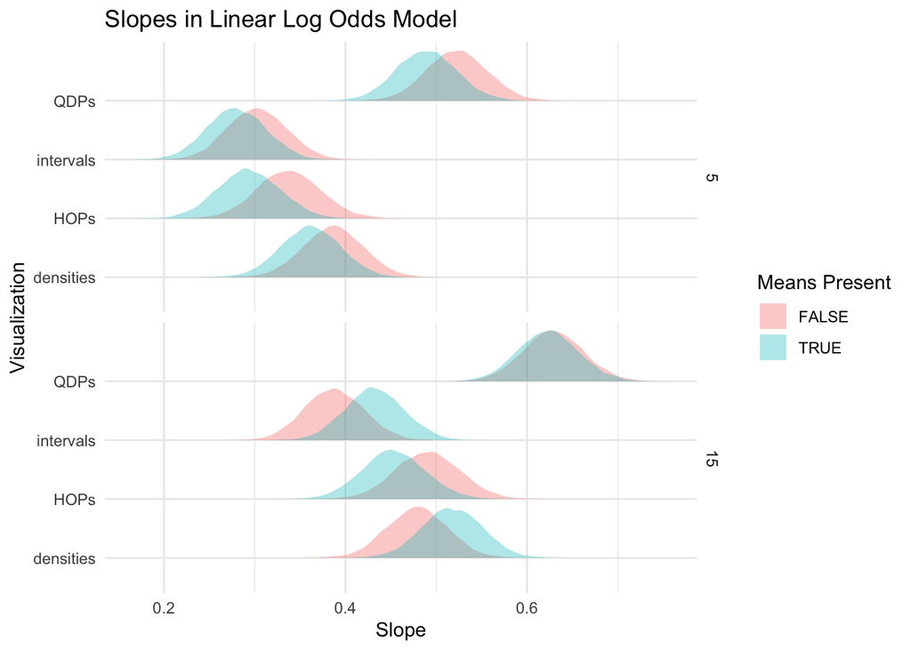

```r
model_df %>%
  group_by(means, sd_diff, condition, trial, start_means) %>%
  data_grid(lo_ground_truth = c(0, 1)) %>%         # get fitted draws (in log odds units) only for ground truth of 0 and 1
  add_fitted_draws(m.p_sup, re_formula = NA) %>%
  compare_levels(.value, by = lo_ground_truth) %>% # calculate the difference between fits at 1 and 0 (i.e., slope)
  rename(slope = .value) %>%
  group_by(means, sd_diff, condition, .draw) %>%   # group by predictors to keep
  summarise(slope = mean(slope)) %>%               # marginalize out other predictors by taking a weighted average
  ggplot(aes(x = slope, y = condition, group = means, fill = means)) +
  stat_slabh(alpha = 0.35) +
  labs(
    title = "Slopes in Linear Log Odds Model",
    x = "Slope",
    y = "Visualization",
    fill = "Means Present"
  ) +
  theme_minimal() +
  facet_grid(sd_diff ~ .)
```

We’ll break this chart down into contrasts and contrasts of contrasts to do some visual reliability testing.

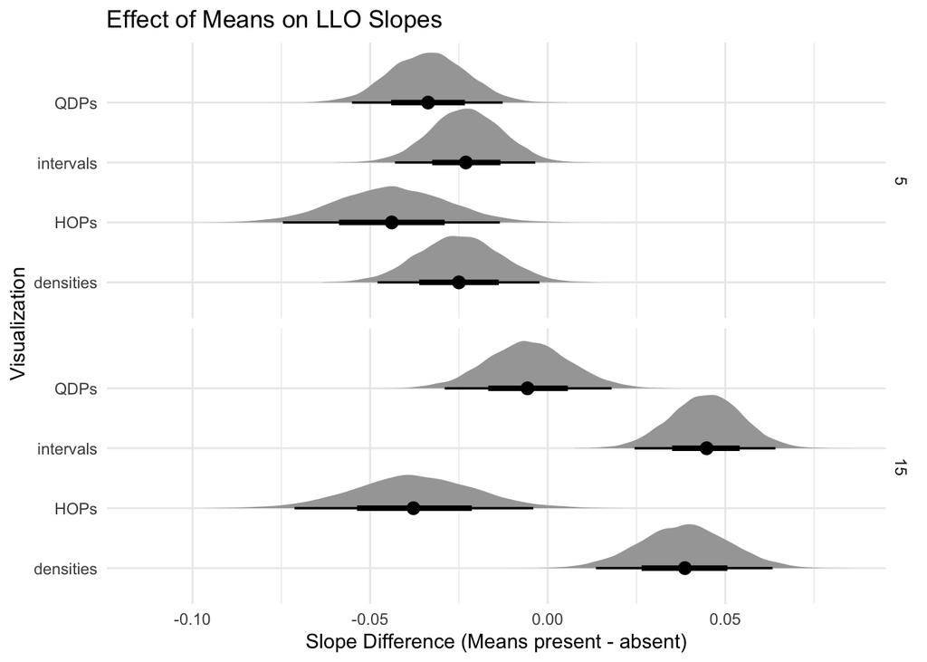

```r
model_df %>%
  group_by(means, sd_diff, condition, trial, start_means) %>%
  data_grid(lo_ground_truth = c(0, 1)) %>%         # get fitted draws (in log odds units) only for ground truth of 0 and 1
  add_fitted_draws(m.p_sup, re_formula = NA) %>%
  compare_levels(.value, by = lo_ground_truth) %>% # calculate the difference between fits at 1 and 0 (i.e., slope)
  rename(slope = .value) %>%
  group_by(means, sd_diff, condition, .draw) %>%   # group by predictors to keep
  summarise(slope = mean(slope)) %>%               # marginalize out other predictors by taking a weighted average
  compare_levels(slope, by = means) %>%            # contrast mean present - absent
  ggplot(aes(x = slope, y = condition)) +
  stat_halfeyeh() +
  labs(
    title = "Effect of Means on LLO Slopes",
    x = "Slope Difference (Means present - absent)",
    y = "Visualization"
  ) +
  theme_minimal() +
  facet_grid(sd_diff ~ .)
```

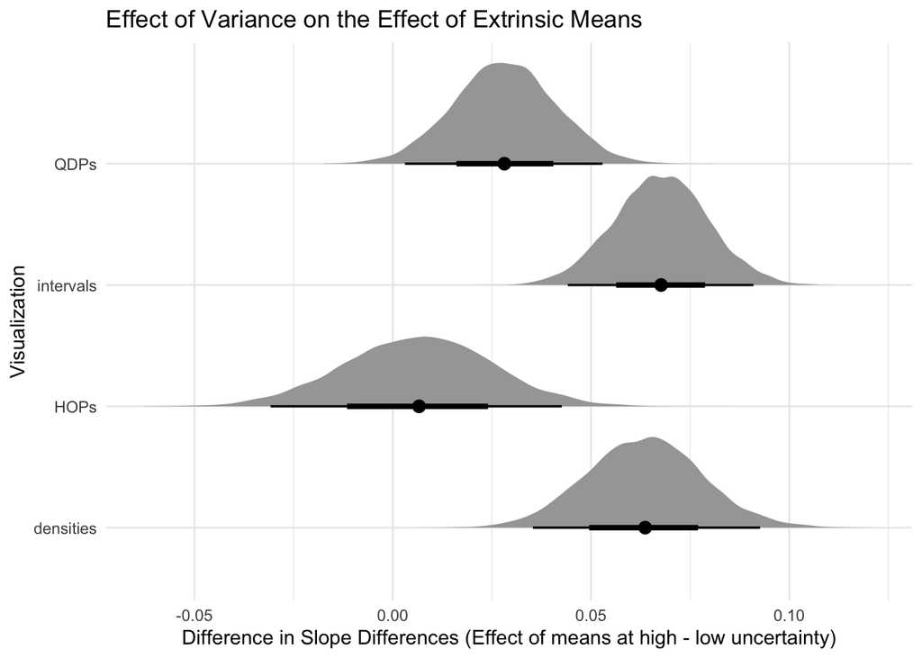

```r
model_df %>%
  group_by(means, sd_diff, condition, trial, start_means) %>%
  data_grid(lo_ground_truth = c(0, 1)) %>%         # get fitted draws (in log odds units) only for ground truth of 0 and 1
  add_fitted_draws(m.p_sup, re_formula = NA) %>%
  compare_levels(.value, by = lo_ground_truth) %>% # calculate the difference between fits at 1 and 0 (i.e., slope)
  rename(slope = .value) %>%
  group_by(means, sd_diff, condition, .draw) %>%   # group by predictors to keep
  summarise(slope = mean(slope)) %>%               # marginalize out other predictors by taking a weighted average
  compare_levels(slope, by = means) %>%            # contrast mean present - absent
  compare_levels(slope, by = sd_diff) %>%          # contrast sd_diff high - low (I think)
  ggplot(aes(x = slope, y = condition)) +
  stat_halfeyeh() +
  labs(
    title = "Effect of Variance on the Effect of Extrinsic Means",
    x = "Difference in Slope Differences (Effect of means at high - low uncertainty)",
    y = "Visualization"
  ) +
  theme_minimal()
```

It looks like extrinsic means lead to greater underestimation of probability of superiority (lower LLO slopes) when variance is low, regardless of visualization condition. This is the effect we expected to see. Surprisingly, the impact of extrinsic means does not seem to depend on the intinsic salience of the mean in the uncertainty visualization conditions. At high levels of variance, extrinsic means improve slopes for intervals and densities but still reduce slopes for HOPs. *These results suggest that adding extrinsic means is not a good design choice for HOPs or when the distributions visualized on a common axis differ in their variance*.

Effect of means on slopes, marginalizing across visualization condition.

```r
model_df %>%
  group_by(means, sd_diff, condition, trial, start_means) %>%
  data_grid(lo_ground_truth = c(0, 1)) %>%          # get fitted draws (in log odds units) only for ground truth of 0 and 1
  add_fitted_draws(m.p_sup, re_formula = NA) %>%
  compare_levels(.value, by = lo_ground_truth) %>%  # calculate the difference between fits at 1 and 0 (i.e., slope)
  rename(slope = .value) %>%
  group_by(means, sd_diff, .draw) %>%               # group by predictors to keep
  summarise(slope = mean(slope)) %>%                # marginalize out other predictors by taking a weighted average
  compare_levels(slope, by = means) %>%             # contrast mean present - absent
  mean_qi()
```

```
## # A tibble: 2 x 8
## # Groups:   means [1]
##   means        sd_diff    slope   .lower  .upper .width .point .interval
##   <fct>        <fct>      <dbl>    <dbl>   <dbl>  <dbl> <chr>  <chr>
## 1 TRUE - FALSE 5       -0.0314  -0.0437  -0.0195   0.95 mean   qi
## 2 TRUE - FALSE 15       0.00999 -0.00300  0.0229   0.95 mean   qi
```

Effect of adding means on predicted error, marginalizing across conditions.

```r
model_df %>%
  data_grid(lo_ground_truth, means, sd_diff, condition, trial, start_means) %>%
  add_predicted_draws(m.p_sup, re_formula = NA, n = 5000, seed = 1234) %>%
  mutate(est_error = plogis(.prediction) - plogis(lo_ground_truth)) %>% # calculate estimation error
  compare_levels(est_error, by = means) %>%                             # contrast mean present - absent
  group_by(means, sd_diff) %>%                                          # group by predictors to keep
  mean_qi(est_error)
```

```
## # A tibble: 2 x 8
## # Groups:   means [1]
##   means        sd_diff est_error .lower .upper .width .point .interval
##   <fct>        <fct>       <dbl>  <dbl>  <dbl>  <dbl> <chr>  <chr>
## 1 TRUE - FALSE 5        -0.00802 -0.250  0.234   0.95 mean   qi
## 2 TRUE - FALSE 15        0.00688 -0.211  0.231   0.95 mean   qi
```

Effect of adding means to intervals, densities, and HOPs at high variance.

```r
model_df %>%
  filter(condition%in% c("intervals", "densities", "HOPs") & sd_diff == 15) %>%
  group_by(means, sd_diff, condition, trial, start_means) %>%
  data_grid(lo_ground_truth = c(0, 1)) %>%         # get fitted draws (in log odds units) only for ground truth of 0 and 1
  add_fitted_draws(m.p_sup, re_formula = NA) %>%
  compare_levels(.value, by = lo_ground_truth) %>% # calculate the difference between fits at 1 and 0 (i.e., slope)
  rename(slope = .value) %>%
  group_by(means, sd_diff, condition, .draw) %>%   # group by predictors to keep
  summarise(slope = mean(slope)) %>%               # marginalize out other predictors by taking a weighted average
  compare_levels(slope, by = means) %>%            # contrast mean present - absent
  mean_qi()
```

```
## # A tibble: 3 x 9
## # Groups:   means, sd_diff [2]
##   means       sd_diff condition   slope  .lower   .upper .width .point .interval
##   <fct>       <fct>   <chr>       <dbl>   <dbl>    <dbl>  <dbl> <chr>  <chr>
## 1 TRUE - FAL… 15      densities  0.0385  0.0136  0.0633    0.95 mean   qi
## 2 TRUE - FAL… 15      HOPs      -0.0376 -0.0713 -0.00404   0.95 mean   qi
## 3 TRUE - FAL… 15      intervals  0.0446  0.0245  0.0641    0.95 mean   qi
```

Effect of adding means to intervals, densities, and HOPs at high variance on predicted error.

```r
model_df %>%
  data_grid(lo_ground_truth, means, sd_diff, condition, trial, start_means) %>%
  filter(condition %in% c("intervals", "densities","HOPs") & sd_diff == 15) %>%
  add_predicted_draws(m.p_sup, re_formula = NA, n = 5000, seed = 1234) %>%
  mutate(est_error = plogis(.prediction) - plogis(lo_ground_truth)) %>% # calculate estimation error
  compare_levels(est_error, by = means) %>%                             # contrast mean present - absent
  group_by(means, sd_diff, condition) %>%                               # group by predictors to keep
  mean_qi(est_error)
```

```
## # A tibble: 3 x 9
## # Groups:   means, sd_diff [2]
##   means        sd_diff condition est_error .lower .upper .width .point .interval
##   <fct>        <fct>   <chr>         <dbl>  <dbl>  <dbl>  <dbl> <chr>  <chr>
## 1 TRUE - FALSE 15      densities   0.0102  -0.188  0.222   0.95 mean   qi
## 2 TRUE - FALSE 15      HOPs        0.00365 -0.266  0.275   0.95 mean   qi
## 3 TRUE - FALSE 15      intervals   0.0150  -0.191  0.231   0.95 mean   qi
```

### Visualization Effects

We preregistered comparisons of LLO slopes in each uncertainty visualization condition, marginalizing across other predictors.

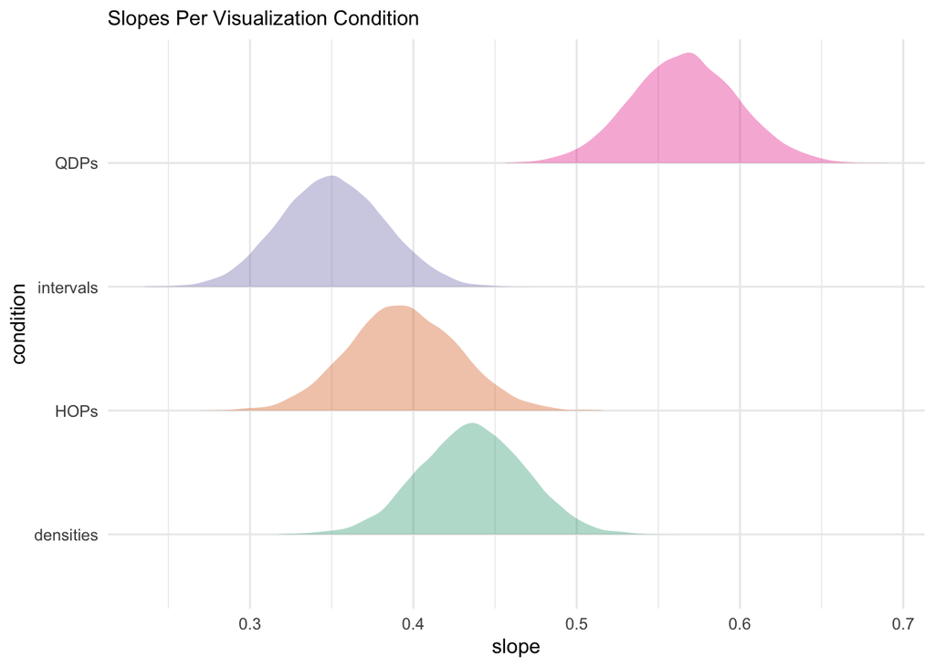

```r
model_df %>%
  group_by(means, sd_diff, condition, trial, start_means) %>%
  data_grid(lo_ground_truth = c(0, 1)) %>%          # get fitted draws (in log odds units) only for ground truth of 0 and 1
  add_fitted_draws(m.p_sup, re_formula = NA) %>%
  compare_levels(.value, by = lo_ground_truth) %>%  # calculate the difference between fits at 1 and 0 (i.e., slope)
  rename(slope = .value) %>%
  group_by(condition, .draw) %>%                    # group by predictors to keep
  summarise(slope = mean(slope)) %>%                # marginalize out means present/absent by taking a weighted average
  ggplot(aes(x = slope, y = condition, fill = condition)) +
  stat_slabh(alpha = 0.35) +
  scale_fill_brewer(type = "qual", palette = 2) +
  labs(subtitle = "Slopes Per Visualization Condition") +
  theme_minimal() +
  theme(legend.position = "none")
```

Let’s look at contrasts between visualization conditions to get a sense of which differences are reliable.

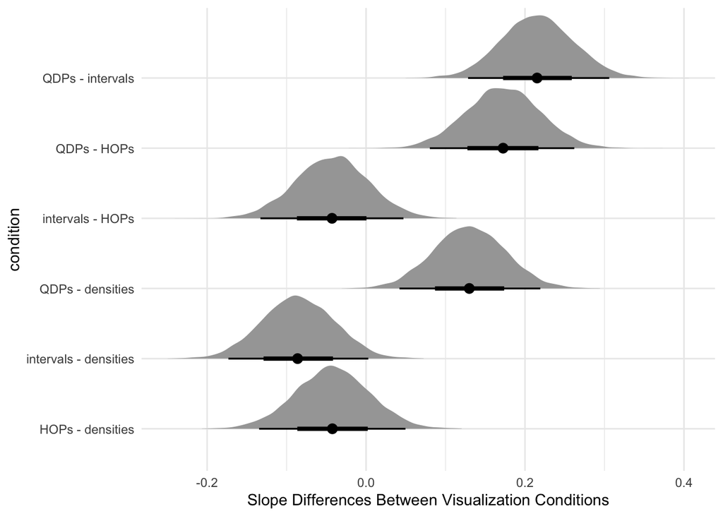

```r
model_df %>%
  group_by(means, sd_diff, condition, trial, start_means) %>%
  data_grid(lo_ground_truth = c(0, 1)) %>%          # get fitted draws (in log odds units) only for ground truth of 0 and 1
  add_fitted_draws(m.p_sup, re_formula = NA) %>%
  compare_levels(.value, by = lo_ground_truth) %>%  # calculate the difference between fits at 1 and 0 (i.e., slope)
  rename(slope = .value) %>%
  group_by(condition, .draw) %>%                    # group by predictors to keep
  summarise(slope = mean(slope)) %>%                # marginalize out means present/absent by taking a weighted average
  compare_levels(slope, by = condition) %>%
  # compare_levels(slope, by = condition, comparison = list(c("QDPs", "intervals"), c("QDPs", "HOPs"), c("QDPs", "densities"), c("densities", "intervals"))) %>%                                  # show only reliable contrasts
  ggplot(aes(x = slope, y = condition)) +
  stat_halfeyeh() +
  labs(x = "Slope Differences Between Visualization Conditions") +
  theme_minimal()
```

The chart above shows only the contrasts between quantile dotplots and each other conditions are reliable.

Slope estimates per visualization condition.

```r
#slopes
model_df %>%
  group_by(means, sd_diff, condition, trial, start_means) %>%
  data_grid(lo_ground_truth = c(0, 1)) %>%          # get fitted draws (in log odds units) only for ground truth of 0 and 1
  add_fitted_draws(m.p_sup, re_formula = NA) %>%
  compare_levels(.value, by = lo_ground_truth) %>%  # calculate the difference between fits at 1 and 0 (i.e., slope)
  rename(slope = .value) %>%
  group_by(condition, .draw) %>%                    # group by predictors to keep
  summarise(slope = mean(slope)) %>%
  mean_qi()
```

```
## # A tibble: 4 x 7
##   condition slope .lower .upper .width .point .interval
##   <chr>     <dbl>  <dbl>  <dbl>  <dbl> <chr>  <chr>
## 1 densities 0.436  0.372  0.499   0.95 mean   qi
## 2 HOPs      0.394  0.329  0.460   0.95 mean   qi
## 3 intervals 0.350  0.289  0.413   0.95 mean   qi
## 4 QDPs      0.566  0.503  0.631   0.95 mean   qi
```

Let’s check out the intercepts per condition as well. We will use these values as well as the slopes above to generate a figure explaining the LLO model. We also want to see that these values are not too different from zero (i.e., 50% probability of superiority).

```r
# intercepts
model_df %>%
  group_by(means, sd_diff, condition, trial, start_means) %>%
  data_grid(lo_ground_truth = c(0)) %>%             # get fitted draws (in log odds units) only for ground truth of 0
  add_fitted_draws(m.p_sup, re_formula = NA) %>%
  rename(intercept = .value) %>%
  group_by(condition, .draw) %>%                    # group by predictors to keep
  summarise(intercept = mean(intercept)) %>%
  mean_qi()
```

```
## # A tibble: 4 x 7
##   condition intercept   .lower .upper .width .point .interval
##   <chr>         <dbl>    <dbl>  <dbl>  <dbl> <chr>  <chr>
## 1 densities   0.00271 -0.0121  0.0176   0.95 mean   qi
## 2 HOPs       -0.00896 -0.0281  0.0102   0.95 mean   qi
## 3 intervals   0.00615 -0.00916 0.0212   0.95 mean   qi
## 4 QDPs        0.00711 -0.00861 0.0224   0.95 mean   qi
```

Predicted error per visualization condition.

```r
model_df %>%
  data_grid(lo_ground_truth, means, sd_diff, condition, trial, start_means) %>%
  add_predicted_draws(m.p_sup, re_formula = NA, n = 5000, seed = 1234) %>%
  mutate(est_error = plogis(.prediction) - plogis(lo_ground_truth)) %>% # calculate estimation error
  group_by(condition) %>%                                               # group by predictors to keep
  mean_qi(est_error)
```

```
## # A tibble: 4 x 7
##   condition est_error .lower .upper .width .point .interval
##   <chr>         <dbl>  <dbl>  <dbl>  <dbl> <chr>  <chr>
## 1 densities   -0.124  -0.362 0.0287   0.95 mean   qi
## 2 HOPs        -0.140  -0.426 0.0688   0.95 mean   qi
## 3 intervals   -0.146  -0.394 0.0296   0.95 mean   qi
## 4 QDPs        -0.0891 -0.270 0.0353   0.95 mean   qi
```

### Posterior Predictions

Let’s look at predicted magnitude estimates to try to help with the interpretation of LLO slope as a metric.

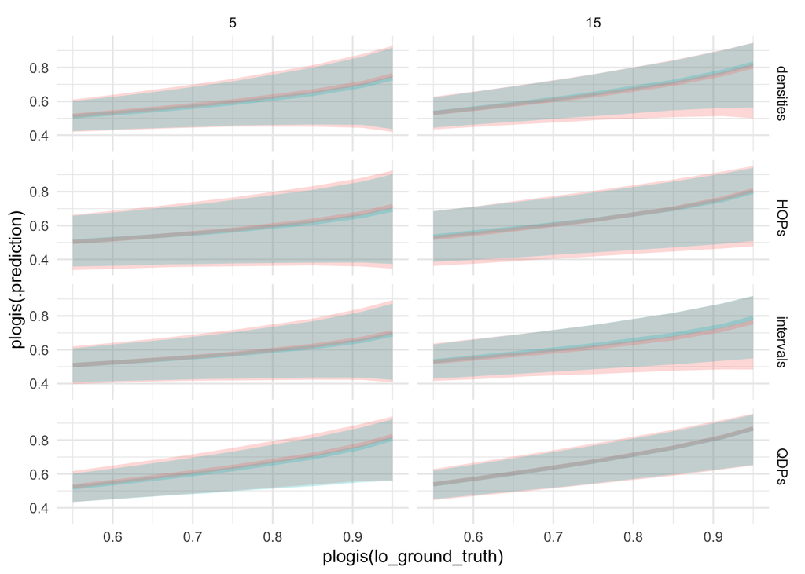

```r
model_df %>%
  data_grid(lo_ground_truth, means, sd_diff, condition, start_means, trial) %>%
  add_predicted_draws(m.p_sup, re_formula = NA, n = 500) %>%
  ggplot(aes(x = plogis(lo_ground_truth), y = plogis(.prediction), color = means, fill = means)) +
  stat_lineribbon(.width = c(.95), alpha = .25, show.legend = FALSE) +
  theme_minimal() +
  facet_grid(condition ~ sd_diff)
```

I find it hard to see the slope differences on this chart. The noise in posterior predictions just swamps the signal we are able to measure as slopes in the linear log odds model.

We can do a little better at showing the effect of interest by removing uncertainty in the prediction, but this seems a little antithetical to the whole point of the paper.

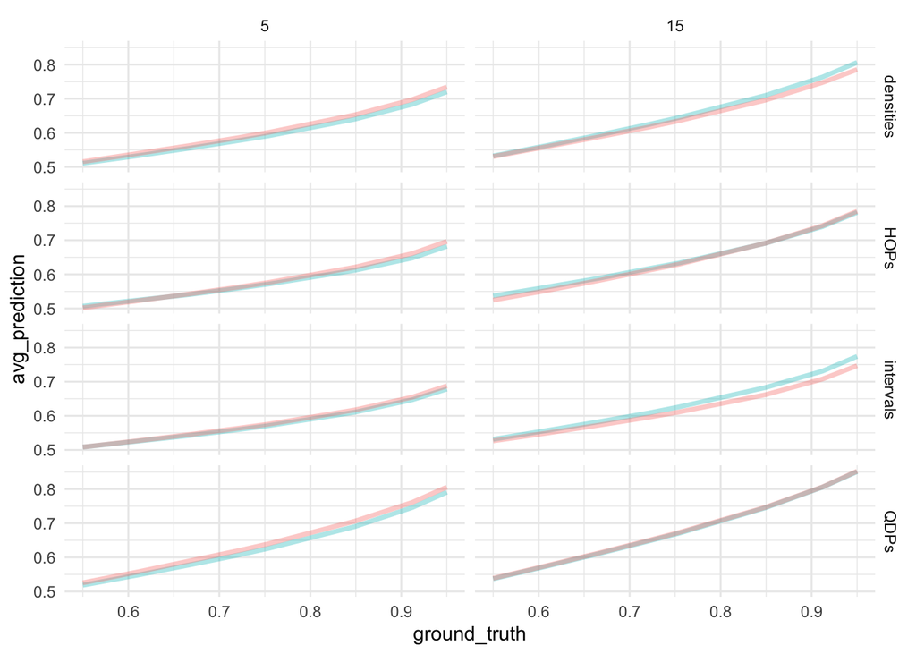

```r
model_df %>%
  data_grid(lo_ground_truth, means, sd_diff, condition, start_means, trial) %>%
  add_predicted_draws(m.p_sup, re_formula = NA, n = 500) %>%
  group_by(lo_ground_truth, means, sd_diff, condition) %>% # marginalize
  mutate(
    ground_truth = plogis(lo_ground_truth),
    avg_prediction = mean(plogis(.prediction))
  ) %>%
  ggplot(aes(x = ground_truth, y = avg_prediction, color = means, fill = means)) +
  stat_lineribbon(.width = c(.95), alpha = .35, show.legend = FALSE) +
  theme_minimal() +
  # coord_cartesian(ylim = c(0, 1)) +
  facet_grid(condition ~ sd_diff)
```

We can also look at predicted errors in estimated probability of superiority to give a different view, although this isn’t much better.

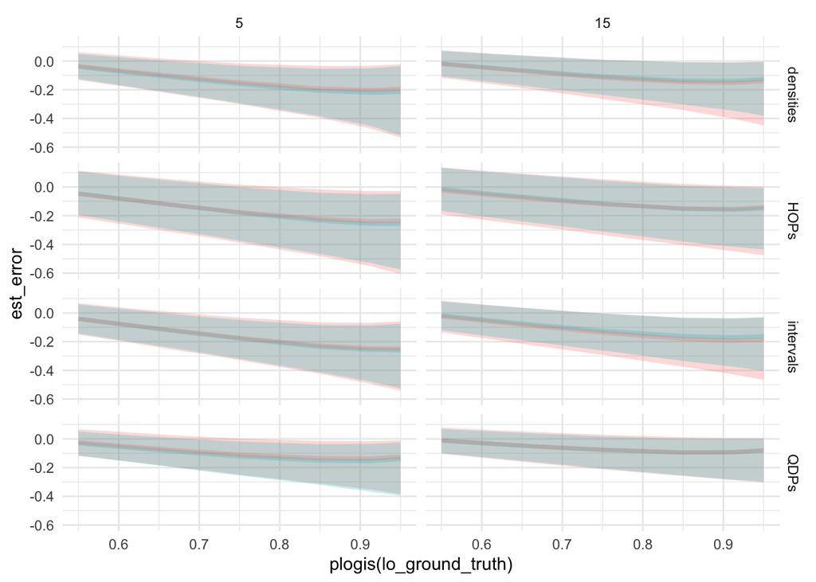

```r
model_df %>%
  data_grid(lo_ground_truth, means, sd_diff, condition, start_means, trial) %>%
  add_predicted_draws(m.p_sup, re_formula = NA, n = 500) %>%
  mutate(est_error = plogis(.prediction) - plogis(lo_ground_truth)) %>% # calculate estimation error
  ggplot(aes(x = plogis(lo_ground_truth), y = est_error, color = means, fill = means)) +
  stat_lineribbon(.width = c(.95), alpha = .25, show.legend = FALSE) +
  theme_minimal() +
  facet_grid(condition ~ sd_diff)
```

It may be best to just describe posterior predictions in term of marginal predicted average error for each of the comparisons that we care about.

## Intervention Decisions

Next, we load in the model of intervention decisions that we arrived at through a process of model expansion described in our preregistration[https://osf.io/9kpmb]. This is a hierachical logistic regression modeling the probability that chart users choose to pay for an intervention based on its effect size compared to status quo if they do not pay. See the paper and **experiment/analysis/InterventionDecisions.Rmd** in the supplemental materials for details.

```r
m.decisions <- brm(
  data = model_df, family = bernoulli(link = "logit"),
  formula = bf(intervene ~ (1 + evidence*means*sd_diff + evidence*trial|worker_id) + evidence*means*sd_diff*condition*start_means + evidence*condition*trial),
  prior = c(prior(normal(0, 1), class = Intercept),
            prior(normal(1, 1), class = b, coef = evidence),
            prior(normal(0, 0.5), class = b),
            prior(normal(0, 0.5), class = sd),
            prior(lkj(4), class = cor)),
  iter = 8000, warmup = 2000, chains = 2, cores = 2, thin = 2,
  file = "model-fits/logistic_mdl-min_order-r_means_sd_trial2-long_chains")
```

```r
summary(m.decisions)
```

```
##  Family: bernoulli
##   Links: mu = logit
## Formula: intervene ~ (1 + evidence * means * sd_diff + evidence * trial | worker_id) + evidence * means * sd_diff * condition * start_means + evidence * condition * trial
##    Data: model_df (Number of observations: 19892)
## Samples: 2 chains, each with iter = 8000; warmup = 2000; thin = 2;
##          total post-warmup samples = 6000
##
## Group-Level Effects:
## ~worker_id (Number of levels: 622)
##                                                       Estimate Est.Error
## sd(Intercept)                                             1.86      0.09
## sd(evidence)                                              1.25      0.08
## sd(meansTRUE)                                             1.32      0.11
## sd(sd_diff15)                                             1.15      0.09
## sd(trial)                                                 2.51      0.16
## sd(evidence:meansTRUE)                                    0.77      0.11
## sd(evidence:sd_diff15)                                    0.73      0.10
## sd(meansTRUE:sd_diff15)                                   0.73      0.16
## sd(evidence:trial)                                        1.51      0.16
## sd(evidence:meansTRUE:sd_diff15)                          0.67      0.19
## cor(Intercept,evidence)                                   0.54      0.05
## cor(Intercept,meansTRUE)                                 -0.10      0.09
## cor(evidence,meansTRUE)                                   0.06      0.09
## cor(Intercept,sd_diff15)                                 -0.38      0.08
## cor(evidence,sd_diff15)                                  -0.04      0.09
## cor(meansTRUE,sd_diff15)                                  0.24      0.10
## cor(Intercept,trial)                                      0.37      0.06
## cor(evidence,trial)                                       0.14      0.08
## cor(meansTRUE,trial)                                      0.22      0.08
## cor(sd_diff15,trial)                                     -0.05      0.09
## cor(Intercept,evidence:meansTRUE)                        -0.17      0.11
## cor(evidence,evidence:meansTRUE)                         -0.04      0.13
## cor(meansTRUE,evidence:meansTRUE)                         0.45      0.12
## cor(sd_diff15,evidence:meansTRUE)                         0.29      0.12
## cor(trial,evidence:meansTRUE)                             0.16      0.12
## cor(Intercept,evidence:sd_diff15)                        -0.38      0.11
## cor(evidence,evidence:sd_diff15)                         -0.08      0.12
## cor(meansTRUE,evidence:sd_diff15)                        -0.08      0.13
## cor(sd_diff15,evidence:sd_diff15)                         0.64      0.10
## cor(trial,evidence:sd_diff15)                            -0.10      0.12
```

[output cut: 566 more lines]

```
## evidence:meansTRUE:conditionintervals:start_meansTRUE               4924
## evidence:meansTRUE:conditionQDPs:start_meansTRUE                    5110
## evidence:sd_diff15:conditionHOPs:start_meansTRUE                    5468
## evidence:sd_diff15:conditionintervals:start_meansTRUE               5299
## evidence:sd_diff15:conditionQDPs:start_meansTRUE                    5508
## meansTRUE:sd_diff15:conditionHOPs:start_meansTRUE                   5257
## meansTRUE:sd_diff15:conditionintervals:start_meansTRUE              5021
## meansTRUE:sd_diff15:conditionQDPs:start_meansTRUE                   5457
## evidence:meansTRUE:sd_diff15:conditionHOPs:start_meansTRUE          5161
## evidence:meansTRUE:sd_diff15:conditionintervals:start_meansTRUE     5433
## evidence:meansTRUE:sd_diff15:conditionQDPs:start_meansTRUE          5510
##
## Samples were drawn using sampling(NUTS). For each parameter, Eff.Sample
## is a crude measure of effective sample size, and Rhat is the potential
## scale reduction factor on split chains (at convergence, Rhat = 1).
```

Our research questions are about the points of subjective equality (PSE) and just-noticable differences (JND) for this logistic regression model. We derive estimates of these two statistics from the model’s posterior distribution.

```r
# get slopes from linear model
slopes_df <- model_df %>%
  group_by(means, sd_diff, condition, trial, start_means) %>%
  data_grid(evidence = c(0, 1)) %>%
  add_fitted_draws(m.decisions, re_formula = NA, scale = "linear", seed = 1234) %>%
  compare_levels(.value, by = evidence) %>%
  rename(slope = .value)

# get intercepts from linear model
intercepts_df <- model_df %>%
  group_by(means, sd_diff, condition, trial, start_means) %>%
  data_grid(evidence = 0) %>%
  add_fitted_draws(m.decisions, re_formula = NA, scale = "linear", seed = 1234) %>%
  rename(intercept = .value)

# join dataframes for slopes and intercepts, calculate PSE and JND
stats_df <- slopes_df %>%
  full_join(intercepts_df, by = c("means", "sd_diff", "condition", "trial", "start_means", ".draw")) %>%
  mutate(
    # evidence units
    pse = -intercept / slope,
    jnd = qlogis(0.75) / slope,
    # probabilities of winning with the new player
    pse_p_award = exp(pse) / (1 / (unique(model_df$baseline) + 1 / unique(model_df$award_value)) - 1 + exp(pse)) - unique(model_df$baseline) - 1 / unique(model_df$award_value),
    jnd_p_award = exp(jnd) / (1 / (unique(model_df$baseline) + 1 / unique(model_df$award_value)) - 1 + exp(jnd)) - unique(model_df$baseline) - 1 / unique(model_df$award_value)
  )
```

### Points of Subjective Equality (PSE)

PSE describe a chart user’s bias toward or against intervening compared to utility optimal decision criterion on the evidence scale (i.e., a proxy for effect size).

#### Interaction Effects

Let’s also take a look at the interaction effect of extinsic means at difference levels of uncertainty on PSE.

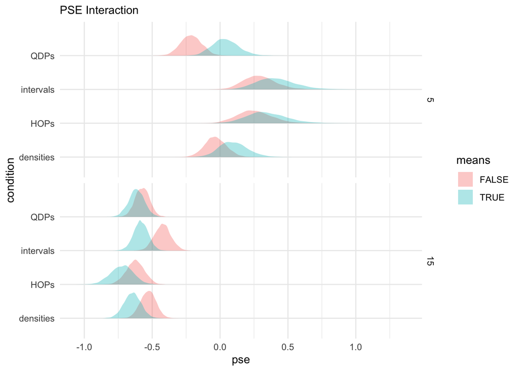

```r
stats_df %>%
  group_by(means, sd_diff, condition, .draw) %>%          # maginalize out other manipulations
  summarise(pse = mean(pse)) %>%
  ggplot(aes(x = pse, y = condition, group = means, fill = means)) +
  stat_slabh(alpha = 0.35) +
  labs(subtitle = "PSE Interaction") +
  theme_minimal() +
  facet_grid(sd_diff ~ .)
```

Let’s look at contrasts for the impact of the mean.

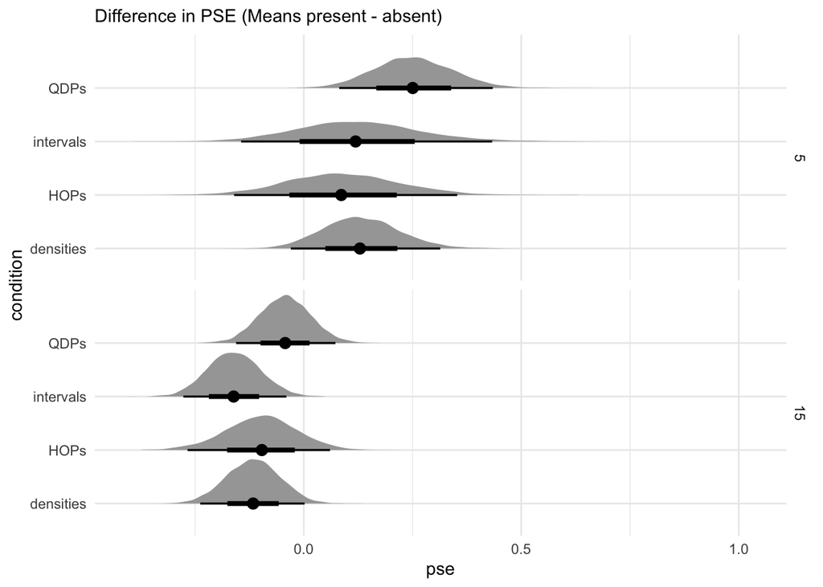

```r
stats_df %>%
  group_by(means, sd_diff, condition, .draw) %>%          # maginalize out other manipulations
  summarise(pse = mean(pse)) %>%
  compare_levels(pse, by = means) %>%
  ggplot(aes(x = pse, y = condition)) +
  stat_halfeyeh() +
  labs(subtitle = "Difference in PSE (Means present - absent)") +
  theme_minimal() +
  facet_grid(sd_diff ~ .)
```

```r
pse_tbl <- stats_df %>%
  group_by(means, sd_diff, condition, .draw) %>%          # maginalize out other manipulations
  summarise(pse = mean(pse)) %>%
  compare_levels(pse, by = means) %>%
  mean_qi()
pse_p_tbl <- stats_df %>%
  group_by(means, sd_diff, condition, .draw) %>%          # maginalize out other manipulations
  summarise(pse_p_award = mean(pse_p_award)) %>%
  compare_levels(pse_p_award, by = means) %>%
  mean_qi()
pse_tbl %>% full_join(pse_p_tbl, by = c("means", "sd_diff", "condition"))
```

```
## # A tibble: 8 x 15
## # Groups:   means, sd_diff [2]
##   means sd_diff condition     pse .lower.x .upper.x .width.x .point.x
##   <fct> <fct>   <chr>       <dbl>    <dbl>    <dbl>    <dbl> <chr>
## 1 TRUE… 5       densities  0.133   -0.0299  0.314       0.95 mean
## 2 TRUE… 5       HOPs       0.0908  -0.160   0.353       0.95 mean
## 3 TRUE… 5       intervals  0.125   -0.144   0.433       0.95 mean
## 4 TRUE… 5       QDPs       0.252    0.0816  0.435       0.95 mean
## 5 TRUE… 15      densities -0.116   -0.238   0.00174     0.95 mean
## 6 TRUE… 15      HOPs      -0.0984  -0.267   0.0603      0.95 mean
## 7 TRUE… 15      intervals -0.160   -0.277  -0.0400      0.95 mean
## 8 TRUE… 15      QDPs      -0.0429  -0.156   0.0727      0.95 mean
## # … with 7 more variables: .interval.x <chr>, pse_p_award <dbl>,
## #   .lower.y <dbl>, .upper.y <dbl>, .width.y <dbl>, .point.y <chr>,
## #   .interval.y <chr>
```

In terms of the direction of effect, extrinsic means seem to consistently bias PSE toward intervention at high variance and away from intervention at low variance. This has the impact of exacerbating biases in decisions compared to when means are absent (with the exception of quantile dotplots at low variance). However, this effect only appears to be reliable for intervals and maybe densities at high variance. We suspect that more data would shrink the uncertainty in these estimates revealing this to be persistent trend.

Quantile dotplots are slightly different than other charts in that they are the only uncertainty encoding that consistently biases users toward intervention, regardless of the level of uncertainty. This means that the positive impact on PSE induced by adding extrinsic means at low uncertainty is debiasing for quantile doplots, which is the only case where we can say that adding means is reliably helpful for decision-making.

To illustrate the unique impact of means on quantile dotplots, let’s compare PSE for quantile dotplots at low variance with and without means.

```r
stats_df %>%
  filter(sd_diff == 5 & condition =="QDPs") %>%
  group_by(means, sd_diff, condition, .draw) %>%          # maginalize out other manipulations
  summarise(
    pse = mean(pse),
    pse_p_award = mean(pse_p_award)
  ) %>%
  mean_qi()
```

```
## # A tibble: 2 x 12
## # Groups:   means, sd_diff [2]
##   means sd_diff condition     pse pse.lower pse.upper pse_p_award
##   <fct> <fct>   <chr>       <dbl>     <dbl>     <dbl>       <dbl>
## 1 FALSE 5       QDPs      -0.213     -0.360   -0.0637    -0.0356
## 2 TRUE  5       QDPs       0.0395    -0.137    0.242      0.00339
## # … with 5 more variables: pse_p_award.lower <dbl>, pse_p_award.upper <dbl>,
## #   .width <dbl>, .point <chr>, .interval <chr>
```

Now, let’s look at constrasts for the impact of the level of variance per condition.

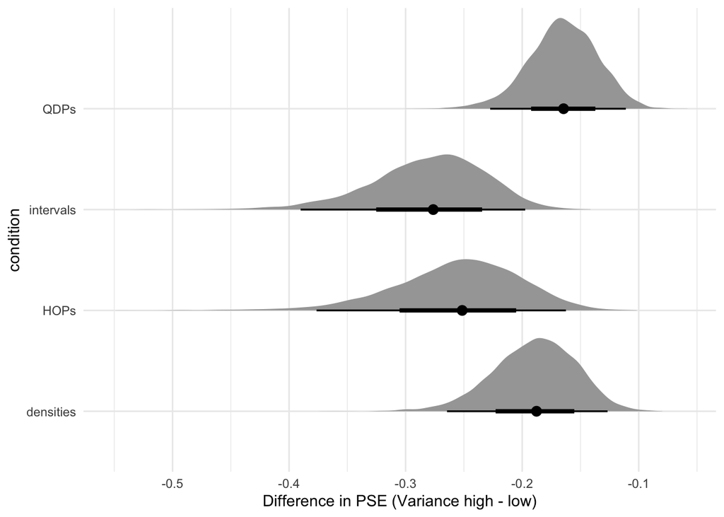

```r
stats_df %>%
  group_by(sd_diff, condition, .draw) %>%          # maginalize out other manipulations (including means present/absent)
  summarise(pse = mean(jnd)) %>%
  compare_levels(pse, by = sd_diff) %>%
  ggplot(aes(x = pse, y = condition)) +
  stat_halfeyeh() +
  labs(x = "Difference in PSE (Variance high - low)") +
  theme_minimal()
```

People seem to intervene more than they should when uncertainty is high in all visualization conditions.

#### The Overall Effect of Adding Extrinsic Means

Let’s examine the effect of means at low vs high variance, marginalizing across visualization conditions.

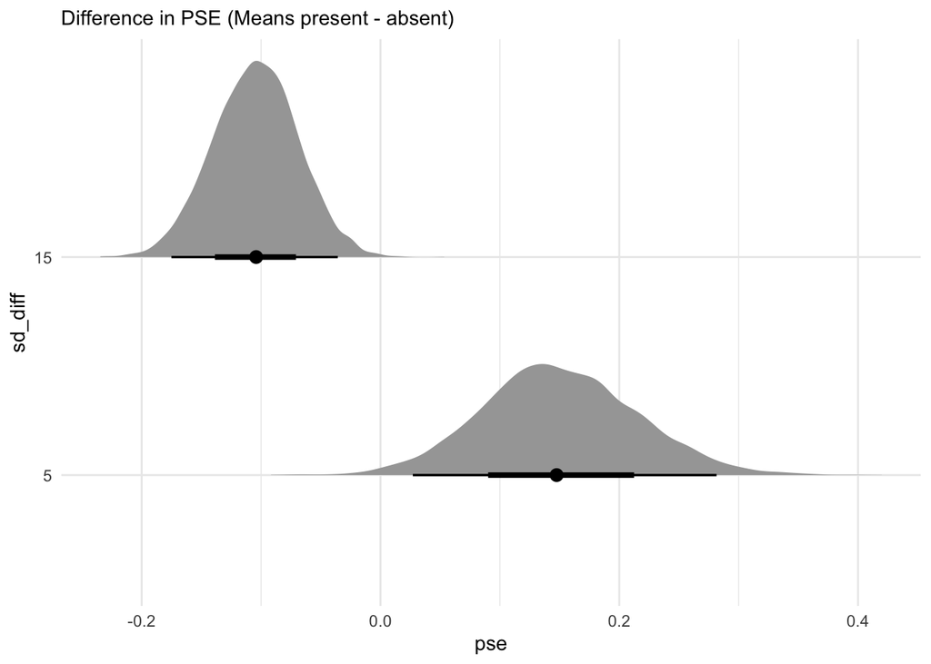

```r
stats_df %>%
  group_by(means, sd_diff, .draw) %>%          # maginalize out other manipulations
  summarise(pse = mean(pse)) %>%
  compare_levels(pse, by = means) %>%
  ggplot(aes(x = pse, y = sd_diff)) +
  stat_halfeyeh() +
  labs(subtitle = "Difference in PSE (Means present - absent)") +
  theme_minimal()
```

```r
pse_tbl <- stats_df %>%
  group_by(means, sd_diff, .draw) %>%
  summarise(pse = mean(pse)) %>%
  compare_levels(pse, by = means) %>%
  mean_qi()
pse_p_tbl <- stats_df %>%
  group_by(means, sd_diff, .draw) %>%
  summarise(pse_p_award = mean(pse_p_award)) %>%
  compare_levels(pse_p_award, by = means) %>%
  mean_qi()
pse_tbl %>% full_join(pse_p_tbl, by = c("means", "sd_diff"))
```

```
## # A tibble: 2 x 14
## # Groups:   means [1]
##   means sd_diff    pse .lower.x .upper.x .width.x .point.x .interval.x
##   <fct> <fct>    <dbl>    <dbl>    <dbl>    <dbl> <chr>    <chr>
## 1 TRUE… 5        0.150   0.0271   0.281      0.95 mean     qi
## 2 TRUE… 15      -0.105  -0.175   -0.0358     0.95 mean     qi
## # … with 6 more variables: pse_p_award <dbl>, .lower.y <dbl>, .upper.y <dbl>,
## #   .width.y <dbl>, .point.y <chr>, .interval.y <chr>
```

It looks like the effect of means is reliable if we marginalize across visualization conditions, which lends credence to the argument that this effect is robust.

Let’s compare the differences in PSE with means added (table above) to PSE without means.

```r
stats_df %>%
  filter(!as.logical(means)) %>%
  group_by(means, sd_diff, .draw) %>%          # maginalize out other manipulations
  summarise(
    pse = mean(pse),
    pse_p_award = mean(pse_p_award)
  ) %>%
  mean_qi()
```

```
## # A tibble: 2 x 11
## # Groups:   means [1]
##   means sd_diff     pse pse.lower pse.upper pse_p_award pse_p_award.low…
##   <fct> <fct>     <dbl>     <dbl>     <dbl>       <dbl>            <dbl>
## 1 FALSE 5        0.0750   -0.0344     0.197     0.00642         -0.00849
## 2 FALSE 15      -0.538    -0.599     -0.476    -0.0954          -0.108
## # … with 4 more variables: pse_p_award.upper <dbl>, .width <dbl>, .point <chr>,
## #   .interval <chr>
```

#### Looking at High vs Low Uncertainty Separately

It seems like the patterns of results for PSE at low vs high variance are different enough that we might want to make different design recommendations depending on the level of uncertainty shown in charts.

Let’s start by looking at contrasts between visualization conditions at low variance. Since means seem to bias users against intervention at low variance (if they have a reliable effect) with the exception of quantile dotplot users, we’ll look specifically at the effectiveness of visualization conditions **without means**.

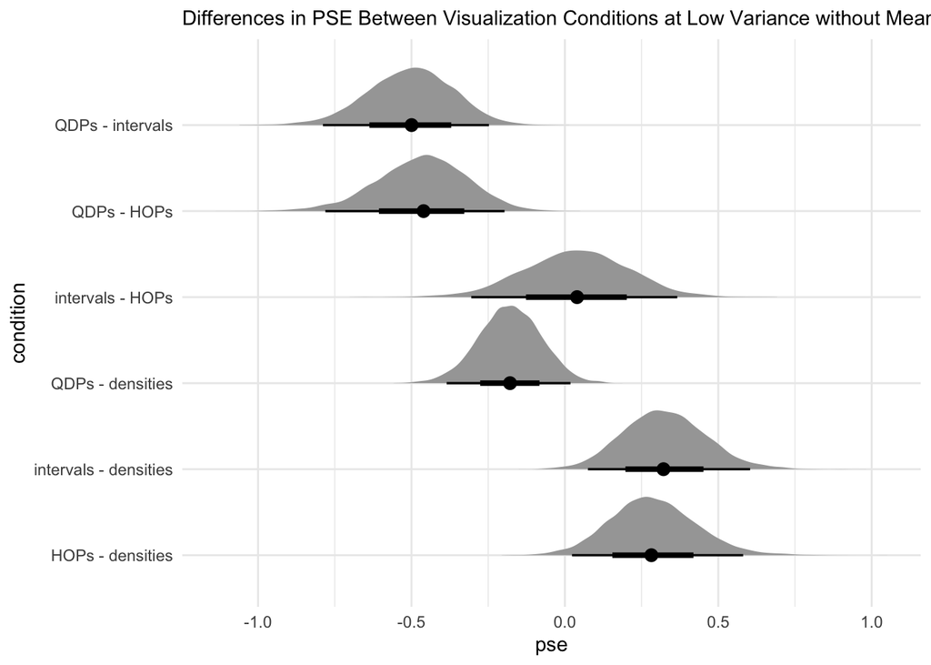

```r
stats_df %>%
  group_by(means, sd_diff, condition, .draw) %>%          # maginalize out other manipulations
  summarise(pse = mean(pse)) %>%
  filter(sd_diff == 5 & !as.logical(means)) %>%
  compare_levels(pse, by = condition) %>%
  ggplot(aes(x = pse, y = condition)) +
  stat_halfeyeh() +
  labs(subtitle = "Differences in PSE Between Visualization Conditions at Low Variance without Means") +
  theme_minimal()
```

Densities without means are the best bet at low variance. They are reliably closer to an unbiased PSE at low variance than intervals, HOPs, and maybe quantile dotplots, suggesting that densities may be preferred when decision aids show distributions with different levels of uncertainty on a common axis.

Note that in the chart above the contrasts between quantile dotplots and invervals or HOPs, respectively, are reliable because the direction of bias is different for quantile dotplots than for invervals or HOPs.

To clarify, *densities without means* are no better than *quantile dotplots with means* in this respect.

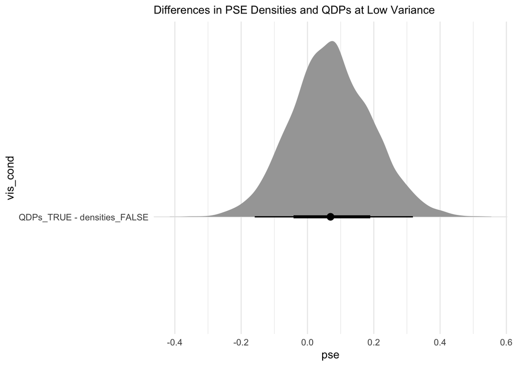

```r
stats_df %>%
  group_by(means, sd_diff, condition, .draw) %>%          # maginalize out other manipulations
  summarise(pse = mean(pse)) %>%
  filter(sd_diff == 5) %>%
  unite(vis_cond, condition, means) %>%
  filter(vis_cond %in% c("densities_FALSE", "QDPs_TRUE")) %>%
  compare_levels(pse, by = vis_cond) %>%
  ggplot(aes(x = pse, y = vis_cond)) +
  stat_halfeyeh() +
  labs(subtitle = "Differences in PSE Densities and QDPs at Low Variance") +
  theme_minimal()
```

PSE for each visualization condition at low variance without means.

```r
stats_df %>%
  filter(sd_diff == 5 & !as.logical(means)) %>%
  group_by(means, sd_diff, condition, .draw) %>%          # maginalize out other manipulations
  summarise(
    pse = mean(pse),
    pse_p_award = mean(pse_p_award)
  ) %>%
  mean_qi()
```

```
## # A tibble: 4 x 12
## # Groups:   means, sd_diff [1]
##   means sd_diff condition     pse pse.lower pse.upper pse_p_award
##   <fct> <fct>   <chr>       <dbl>     <dbl>     <dbl>       <dbl>
## 1 FALSE 5       densities -0.0335   -0.188     0.127     -0.00611
## 2 FALSE 5       HOPs       0.255     0.0210    0.531      0.0324
## 3 FALSE 5       intervals  0.292     0.0775    0.548      0.0350
## 4 FALSE 5       QDPs      -0.213    -0.360    -0.0637    -0.0356
## # … with 5 more variables: pse_p_award.lower <dbl>, pse_p_award.upper <dbl>,
## #   .width <dbl>, .point <chr>, .interval <chr>
```

Now, we’ll consider contrasts between visualization conditions without means at high variance.

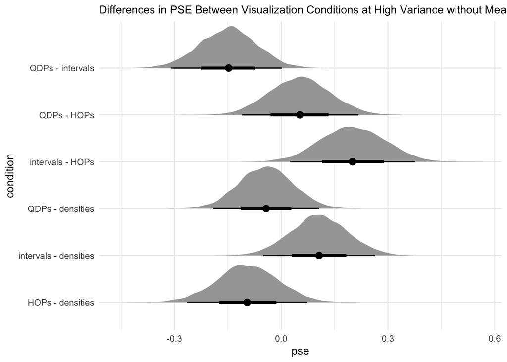

```r
stats_df %>%
  group_by(means, sd_diff, condition, .draw) %>%          # maginalize out other manipulations
  summarise(pse = mean(pse)) %>%
  filter(sd_diff == 15 & !as.logical(means)) %>%
  compare_levels(pse, by = condition) %>%
  ggplot(aes(x = pse, y = condition)) +
  stat_halfeyeh() +
  labs(subtitle = "Differences in PSE Between Visualization Conditions at High Variance without Means") +
  theme_minimal()
```

When we compare visualization conditions without means, looking for the least biased distributional encoding at high variance, intervals are less biased than HOPs and maybe quantile dotplots, but are not reliably less biased than densities.

PSE for each visualization condition at high variance without means.

```r
stats_df %>%
  filter(sd_diff == 15 & !as.logical(means)) %>%
  group_by(means, sd_diff, condition, .draw) %>%          # maginalize out other manipulations
  summarise(
    pse = mean(pse),
    pse_p_award = mean(pse_p_award)
  ) %>%
  mean_qi()
```

```
## # A tibble: 4 x 12
## # Groups:   means, sd_diff [1]
##   means sd_diff condition    pse pse.lower pse.upper pse_p_award
##   <fct> <fct>   <chr>      <dbl>     <dbl>     <dbl>       <dbl>
## 1 FALSE 15      densities -0.530    -0.643    -0.418     -0.0936
## 2 FALSE 15      HOPs      -0.625    -0.759    -0.496     -0.113
## 3 FALSE 15      intervals -0.423    -0.541    -0.302     -0.0727
## 4 FALSE 15      QDPs      -0.573    -0.676    -0.470     -0.102
## # … with 5 more variables: pse_p_award.lower <dbl>, pse_p_award.upper <dbl>,
## #   .width <dbl>, .point <chr>, .interval <chr>
```

#### Visualization Effects

We preregistered comparisons between estimates of PSE per visualization, marginalizing across other manipulations. However, it occurs to us in hindsight that this marginalization corresponds to a visualization designers cannot render, a chart both with and without means. Therefore, we downplay these results compared to the more nuanced interaction effects.

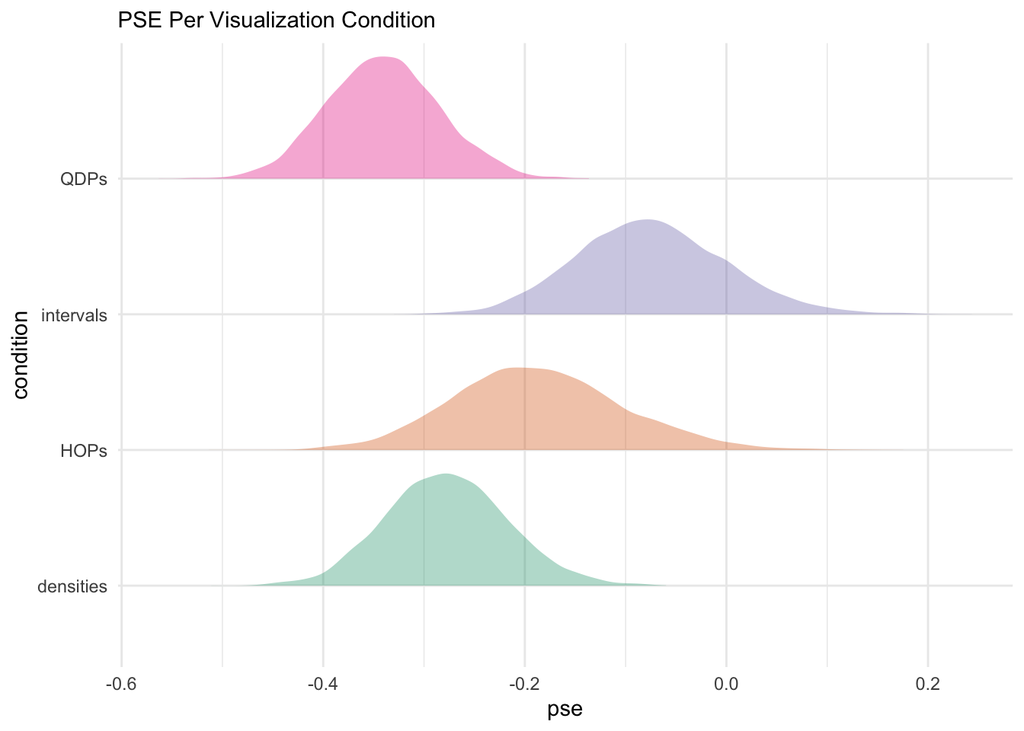

```r
stats_df %>%
  group_by(condition, .draw) %>%          # maginalize out other manipulations
  summarise(pse = mean(pse)) %>%
  ggplot(aes(x = pse, y = condition, fill = condition)) +
  stat_slabh(alpha = 0.35) +
  scale_fill_brewer(type = "qual", palette = 2) +
  labs(subtitle = "PSE Per Visualization Condition") +
  theme_minimal() +
  theme(legend.position = "none")
```

```r
stats_df %>%
  group_by(condition, .draw) %>%
  summarise(
    pse = mean(pse),
    pse_p_award = mean(pse_p_award)
  ) %>%
  mean_qi()
```

```
## # A tibble: 4 x 10
##   condition     pse pse.lower pse.upper pse_p_award pse_p_award.low…
##   <chr>       <dbl>     <dbl>     <dbl>       <dbl>            <dbl>
## 1 densities -0.277     -0.392   -0.153      -0.0515          -0.0711
## 2 HOPs      -0.187     -0.342   -0.0135     -0.0440          -0.0684
## 3 intervals -0.0746    -0.213    0.0795     -0.0252          -0.0441
## 4 QDPs      -0.340     -0.447   -0.228      -0.0614          -0.0804
## # … with 4 more variables: pse_p_award.upper <dbl>, .width <dbl>, .point <chr>,
## #   .interval <chr>
```

Let’s look at contrasts between visualization conditions for visual reliability tests.

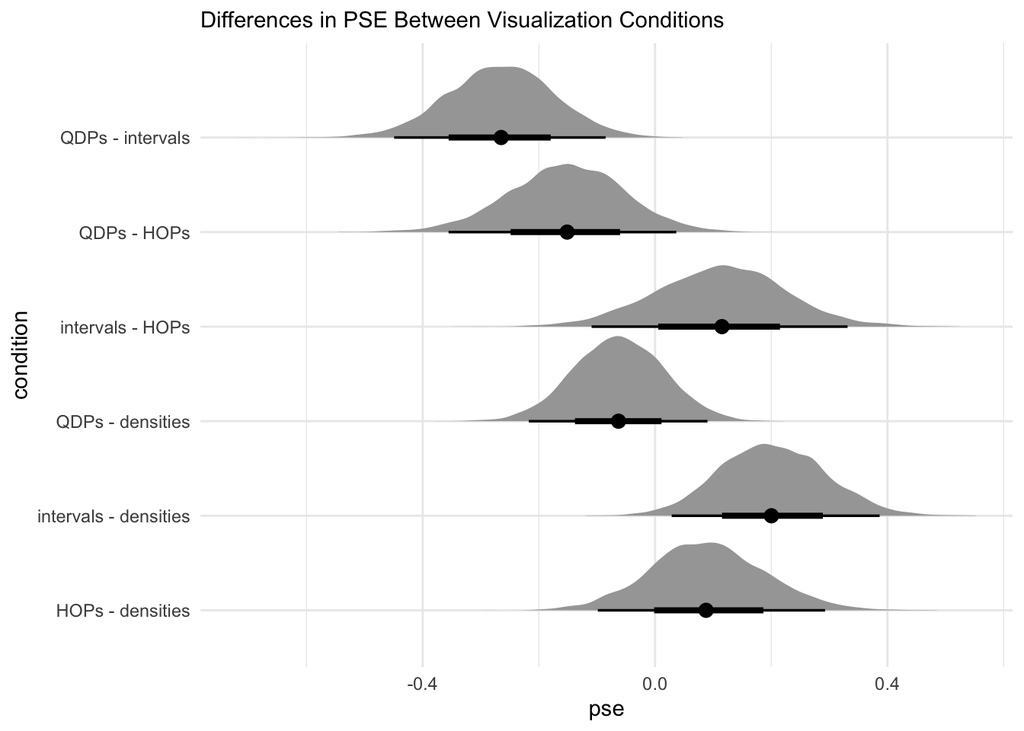

```r
stats_df %>%
  group_by(condition, .draw) %>%          # maginalize out other manipulations
  summarise(pse = mean(pse)) %>%
  compare_levels(pse, by = condition) %>%
  ggplot(aes(x = pse, y = condition)) +
  stat_halfeyeh() +
  labs(subtitle = "Differences in PSE Between Visualization Conditions") +
  theme_minimal()
```

It looks like the point of subjective equality is least biased with intervals, with increasing bias toward intervening (i.e., negative PSE) with HOPs, densities, and quantile dotplots, respectively. Only pairwise differences of intervals minus densities and intervals minus quantile dotplots are reliable.

### Just-Noticeable Differences (JNDs)

JNDs describe a chart user’s sensitivity to effect size information (i.e., evidence) for the purpose of making decisions.

#### Interaction Effects

Since we are interested in the way that extinsic means impact the perception of effect size at difference levels of variance, we also look at how this effect manifests in JNDs.

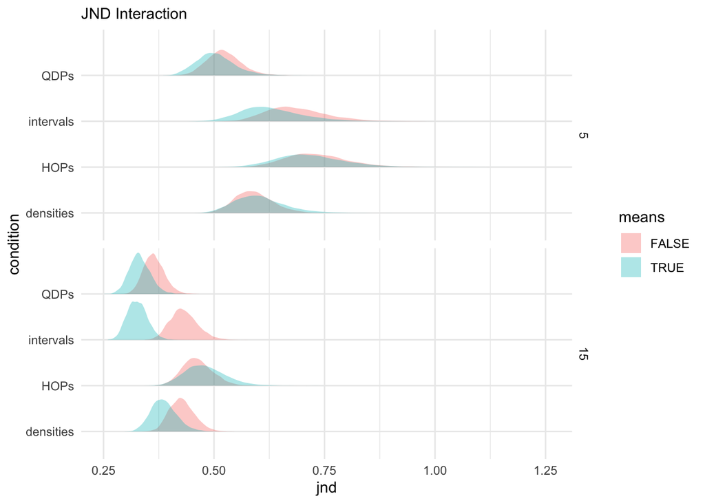

```r
stats_df %>%
  group_by(means, sd_diff, condition, .draw) %>%          # maginalize out other manipulations
  summarise(jnd = mean(jnd)) %>%
  ggplot(aes(x = jnd, y = condition, group = means, fill = means)) +
  stat_slabh(alpha = 0.35) +
  labs(subtitle = "JND Interaction") +
  theme_minimal() +
  facet_grid(sd_diff ~ .)
```

Let’s look at contrasts for the impact of the mean.

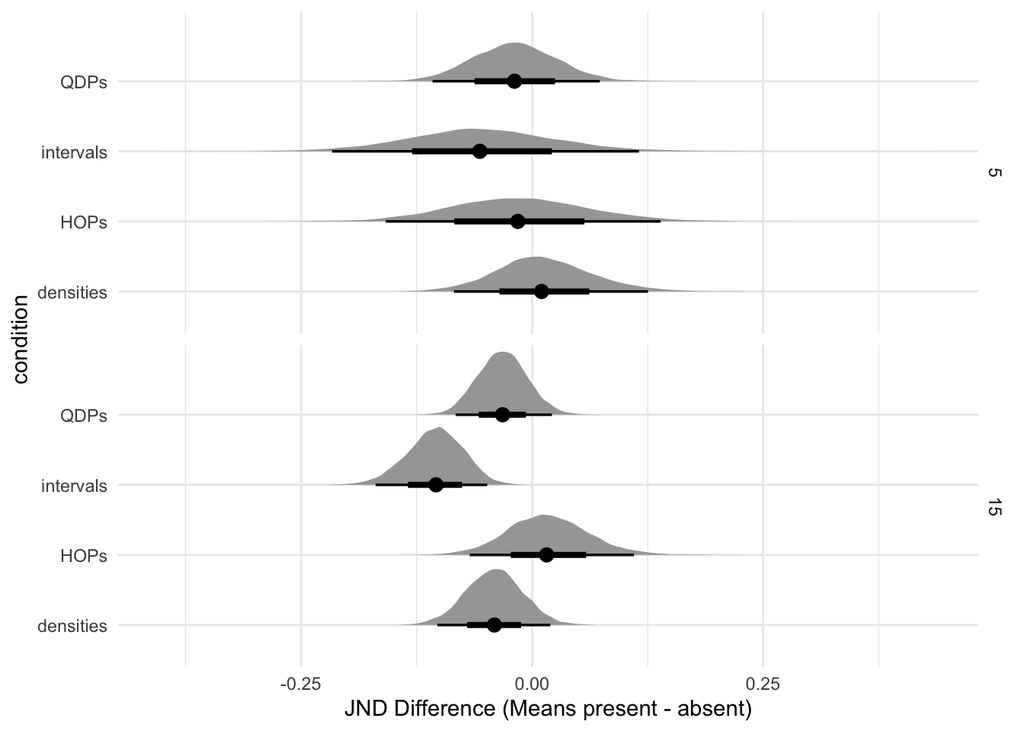

```r
stats_df %>%
  group_by(means, sd_diff, condition, .draw) %>%          # maginalize out other manipulations
  summarise(jnd = mean(jnd)) %>%
  compare_levels(jnd, by = means) %>%
  ggplot(aes(x = jnd, y = condition)) +
  stat_halfeyeh() +
  labs(x = "JND Difference (Means present - absent)") +
  theme_minimal() +
  facet_grid(sd_diff ~ .)
```

Extrinsic means seem to improve sensitivity for intervals at high variance

```r
jnd_tbl <- stats_df %>%
  filter(condition == "intervals" & sd_diff == 15) %>%
  group_by(means, sd_diff, condition, .draw) %>%
  summarise(jnd = mean(jnd)) %>%
  compare_levels(jnd, by = means) %>%
  mean_qi()
jnd_p_tbl <- stats_df %>%
  filter(condition == "intervals" & sd_diff == 15) %>%
  group_by(means, sd_diff, condition, .draw) %>%
  summarise(jnd_p_award = mean(jnd_p_award)) %>%
  compare_levels(jnd_p_award, by = means) %>%
  mean_qi()
jnd_tbl %>% full_join(jnd_p_tbl, by = c("means", "sd_diff", "condition"))
```

```
## # A tibble: 1 x 15
## # Groups:   means, sd_diff [2]
##   means sd_diff condition    jnd .lower.x .upper.x .width.x .point.x .interval.x
##   <fct> <fct>   <chr>      <dbl>    <dbl>    <dbl>    <dbl> <chr>    <chr>
## 1 TRUE… 15      intervals -0.105   -0.169  -0.0486     0.95 mean     qi
## # … with 6 more variables: jnd_p_award <dbl>, .lower.y <dbl>, .upper.y <dbl>,
## #   .width.y <dbl>, .point.y <chr>, .interval.y <chr>
```

Now, let’s look at constrasts for the impact of the level of variance.

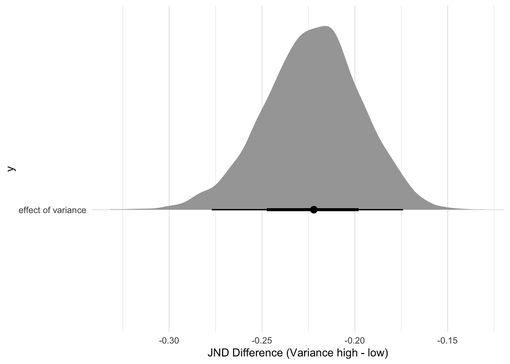

```r
stats_df %>%
  group_by(sd_diff, .draw) %>%          # maginalize out other manipulations (including means present/absent and vis condition)
  summarise(jnd = mean(jnd)) %>%
  compare_levels(jnd, by = sd_diff) %>%
  ggplot(aes(x = jnd, y = "effect of variance")) +
  stat_halfeyeh() +
  labs(x = "JND Difference (Variance high - low)") +
  theme_minimal()
```

Let’s quantify the marginal impact of the level of variance on JNDs.

```r
jnd_tbl <- stats_df %>%
  group_by(sd_diff, .draw) %>%          # maginalize out other manipulations (including condition and means present/absent)
  summarise(jnd = mean(jnd)) %>%
  compare_levels(jnd, by = sd_diff) %>%
  mean_qi()
jnd_p_tbl <- stats_df %>%
  group_by(sd_diff, .draw) %>%          # maginalize out other manipulations (including condition and means present/absent)
  summarise(jnd_p_award = mean(jnd_p_award)) %>%
  compare_levels(jnd_p_award, by = sd_diff) %>%
  mean_qi()
jnd_tbl %>% full_join(jnd_p_tbl, by = c("sd_diff"))
```

```
## # A tibble: 1 x 13
##   sd_diff    jnd .lower.x .upper.x .width.x .point.x .interval.x jnd_p_award
##   <fct>    <dbl>    <dbl>    <dbl>    <dbl> <chr>    <chr>             <dbl>
## 1 15 - 5  -0.223   -0.277   -0.174     0.95 mean     qi              -0.0221
## # … with 5 more variables: .lower.y <dbl>, .upper.y <dbl>, .width.y <dbl>,
## #   .point.y <chr>, .interval.y <chr>
```

Users seem to be consistently more sensitive to evidence (smaller JNDs) when uncertainty is high. This might be because charts in the high uncertainty condition use more of the space on a chart to convey effect size compared to the low uncertainty charts which have a lot of white space such that smaller visual differences convey the same effect size.

#### Visualization Effects

We preregistered comparisons of JNDs per visualization, marginalizing across other manipulations.

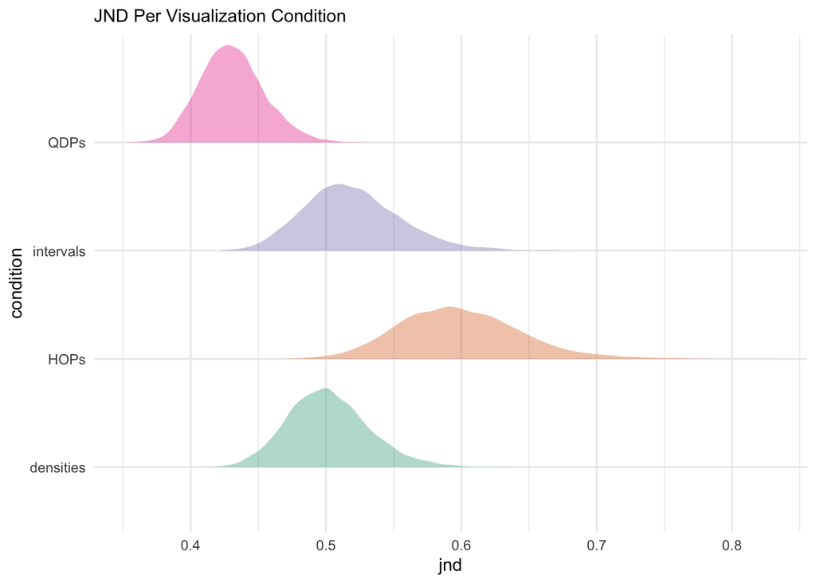

```r
stats_df %>%
  group_by(condition, .draw) %>%          # maginalize out other manipulations
  summarise(jnd = mean(jnd)) %>%
  ggplot(aes(x = jnd, y = condition, fill = condition)) +
  stat_slabh(alpha = 0.35) +
  scale_fill_brewer(type = "qual", palette = 2) +
  labs(subtitle = "JND Per Visualization Condition") +
  theme_minimal() +
  theme(legend.position = "none")
```

```r
stats_df %>%
  group_by(condition, .draw) %>%
  summarise(
    jnd = mean(jnd),
    jnd_p_award = mean(jnd_p_award)
  ) %>%
  mean_qi()
```

```
## # A tibble: 4 x 10
##   condition   jnd jnd.lower jnd.upper jnd_p_award jnd_p_award.low…
##   <chr>     <dbl>     <dbl>     <dbl>       <dbl>            <dbl>
## 1 densities 0.502     0.447     0.567      0.0631           0.0575
## 2 HOPs      0.599     0.520     0.696      0.0727           0.0653
## 3 intervals 0.520     0.458     0.598      0.0635           0.0579
## 4 QDPs      0.431     0.388     0.481      0.0555           0.0510
## # … with 4 more variables: jnd_p_award.upper <dbl>, .width <dbl>, .point <chr>,
## #   .interval <chr>
```

Let’s look at contrasts between visualization conditions for visual reliability tests.

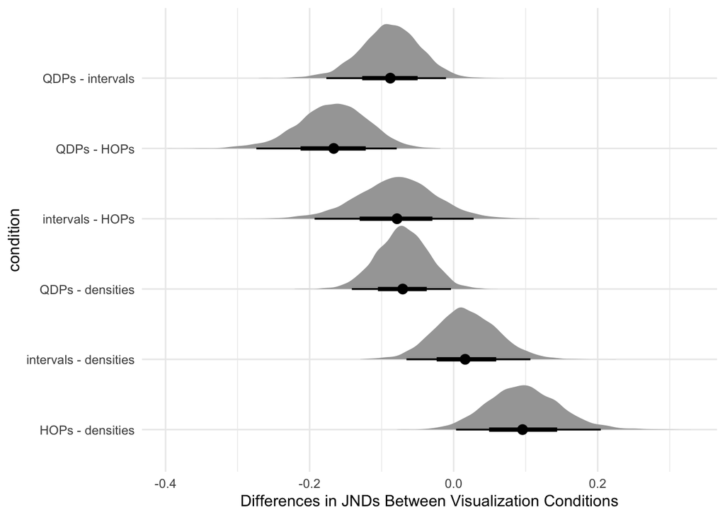

```r
stats_df %>%
  group_by(condition, .draw) %>%          # maginalize out other manipulations
  summarise(jnd = mean(jnd)) %>%
  compare_levels(jnd, by = condition) %>%
  ggplot(aes(x = jnd, y = condition)) +
  stat_halfeyeh() +
  labs(x = "Differences in JNDs Between Visualization Conditions") +
  theme_minimal()
```

It looks like users are most sensitive to evidence (i.e., JNDs are smaller) in the quantile dotplots condition and are least sensitive with HOPs. Only the difference between quantile dotplots and other conditions is reliable.

## Does Perceptual Accuracy Lead to Better Decision-Making?

We want to explore how perceptual bias as measured by LLO slopes impacts decision quality as measured by JND and PSE. To do this, we derive point estimates of estimates LLO slope, JND, and PSE for each worker in our data set and combine these statistics into one dataframe.

```r
# get linear log odds (LLO) slopes per worker
wrkr_llo_slopes_df <- model_df %>%
  group_by(worker_id, means, sd_diff, condition, trial, start_means) %>%
  data_grid(lo_ground_truth = c(0, 1)) %>%          # get fitted draws (in log odds units) only for ground truth of 0 and 1
  add_fitted_draws(m.p_sup, n = 500) %>%
  compare_levels(.value, by = lo_ground_truth) %>%  # calculate the difference between fits at 1 and 0 (i.e., slope)
  rename(llo_slope = .value) %>%
  group_by(worker_id, condition) %>%                # calculate point estimate of marginal LLO slope per worker
  summarise(llo_slope = weighted.mean(llo_slope))
```

```r
# get logistic regression slopes per worker
wrkr_logistic_slopes_df <- model_df %>%
  group_by(worker_id, means, sd_diff, condition, trial, start_means) %>%
  data_grid(evidence = c(0, 1)) %>%
  add_fitted_draws(m.decisions, scale = "linear", n = 500, seed = 1234) %>%
  compare_levels(.value, by = evidence) %>%
  rename(slope = .value)

# get logistic regression intercepts per worker
wrkr_logistic_intercepts_df <- model_df %>%
  group_by(worker_id ,means, sd_diff, condition, trial, start_means) %>%
  data_grid(evidence = 0) %>%
  add_fitted_draws(m.decisions, scale = "linear", n = 500, seed = 1234) %>%
  rename(intercept = .value)

# join dataframes for logistic slopes and intercepts, calculate PSE and JND
wrkr_logistic_stats_df <- wrkr_logistic_slopes_df %>%
  full_join(wrkr_logistic_intercepts_df, by = c("worker_id", "means", "sd_diff", "condition", "trial", "start_means", ".draw")) %>%
  mutate(
    pse = -intercept / slope,
    jnd = qlogis(0.75) / slope
  ) %>%
  group_by(worker_id, condition) %>%  # calculate point estimate of marginal JND and PSE per worker
  summarise(
    pse = weighted.mean(pse),
    jnd = weighted.mean(jnd)
  )
```

```r
# join the dataframes of summary statistics per worker
wrkr_stats_df <- wrkr_llo_slopes_df %>%
  full_join(wrkr_logistic_stats_df, by = c("worker_id", "condition"))
```

Prior work (Khaw et al.) explained bias in PSE in terms of sensitivity to signal as measured by JND. Let’s plot these things together to see if we have a similar correspondence in our data.

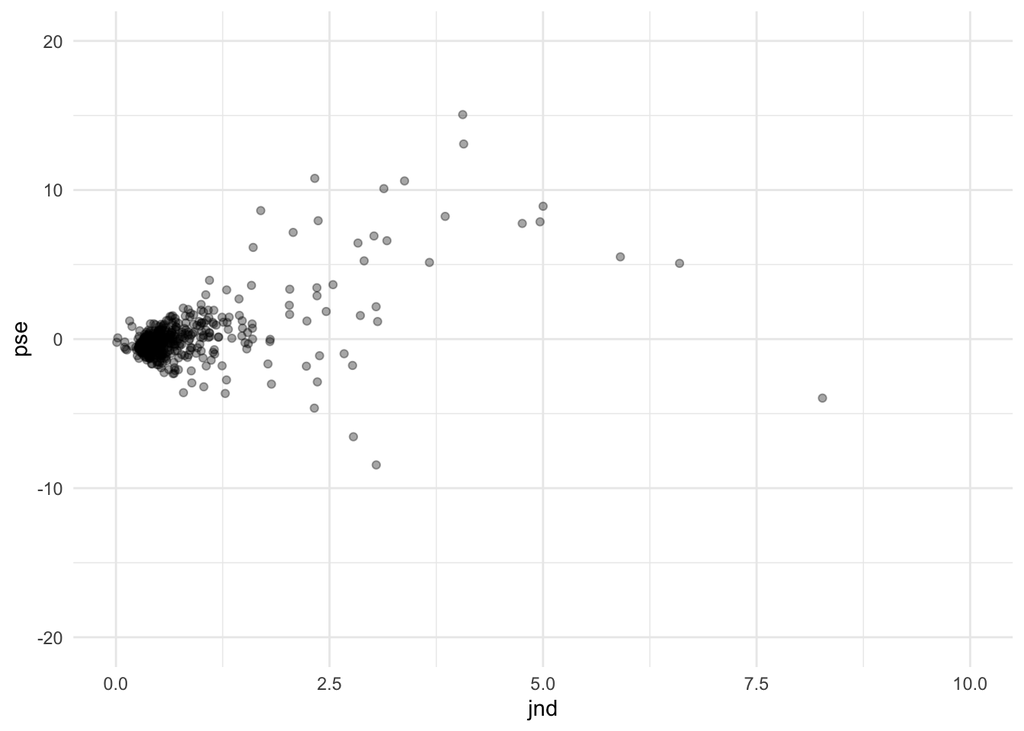

```r
wrkr_stats_df %>%
  filter(jnd > 0) %>%
  ggplot(aes(x = jnd, y = pse)) +
  geom_point(alpha = 0.35) +
  coord_cartesian(
    xlim = c(0, 10),
    ylim = c(-20, 20)
  ) +
  theme_minimal()
```

We see here that PSE closer to zero are predicted by JNDs closer to zero. That is workers who have greater sensitivity to effect size for the purpose of decision-making also tend to make more utility-optimal decisions.

However, since we have a separate task which gauges bias in the perception of effect size, we can also look at how performance on the estimation task predicts performance on the decision task.

Now let’s look at the relationship between LLO slopes and JNDs. This should give a rough indication of how much perceptual accuracy for effect size judgments translates into sensitivity to effect size information for the purpose of decision-making. We’ve had to filter some workers with extreme JNDs out of this view to get a chart we can read. These are the subset of workers with JND estimates in a reasonable range.

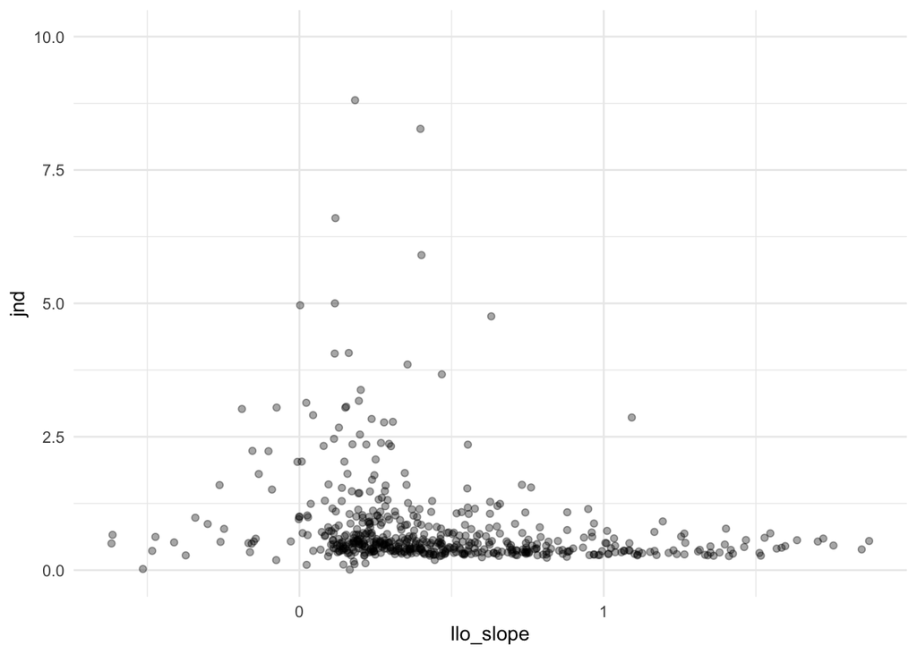

```r
wrkr_stats_df %>%
  filter(jnd > 0) %>%
  ggplot(aes(x = llo_slope, y = jnd)) +
  geom_point(alpha = 0.35) +
  coord_cartesian(ylim = c(0, 10)) +
  theme_minimal()
```

We can see that while more of the high JNDs (indicating insensitivity) are for workers with low LLO slopes (indicating a tendency to underestimate effect size). However, most workers have relatively small JNDs across the full range of observed LLO slopes, suggesting that perceptual accuracy and sensitivity are only loosely linked with additional factors probably impacting decision-making.

What about the relationship between LLO slopes and PSE. This should give a rough sense of how much perceptual bias translates into bias in decision-making. Again, we’ve had to filter some workers with extreme PSE out of this view to get a chart we can read.

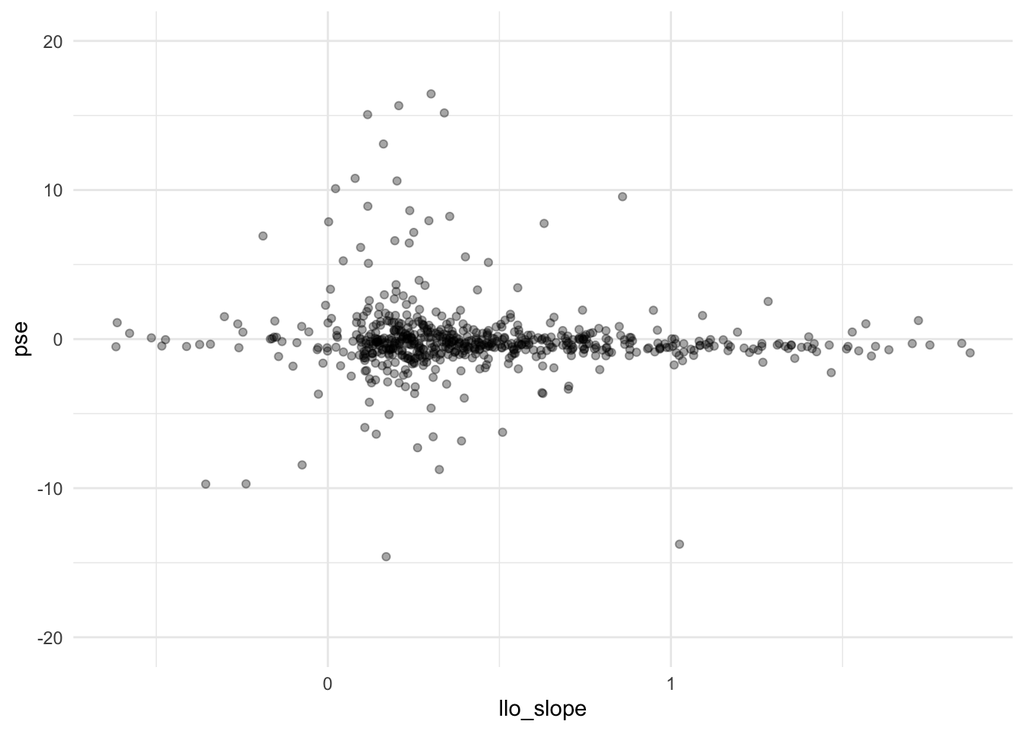

```r
wrkr_stats_df %>%
  ggplot(aes(x = llo_slope, y = pse)) +
  geom_point(alpha = 0.35) +
  coord_cartesian(ylim = c(-20, 20)) +
  theme_minimal()
```

Here again we see that the most extreme biases in decision-making (PSE far from 0) tend to correspond with the most extreme tendency to underestimate effect size (slopes less than 1). While biases in decision-making are less common among users with more accurate effect size judgments, the opposite is not the case: There are many users with poor perceptual accuracy who have close to utility optimal decisions. This suggests that perceptual accuracy does not determine a user’s ability to make a decision. The implication for the visualization community is that we need to seek a better understanding of how performance on these tasks is related.

Part of this mismatch between perceptual performance and decision-making performance may be explained by the fact that out magnitude estimation task was more difficult than the decision task. Some users struggled with the more granular response scale of probability of superiority in pilot testing. By comparison, a binary decision is rather straightforward. We also incentivized the decision task and not the magnitude estimation task. Although we told participants that the best way to maximize their bonus was to answer both questions to the best of their ability, some participants may have sped through the probability of superiority judgments and focused on the decision task. This might explain some of the mismatch between performance on the two tasks.